# Power Law on Network Component Sizes

Gabrielle Lemire’s project

Philip Turk

2021-06-28

### Part One

Following is a plot of the distribution of component sizes for the network ($n$ = 1,258 nodes). I should add that sometimes in this sort of context and with more data (in text analytics, anyway), we would use relative component sizes (here, divided by 1,258). Also, it is not required to explicitly account for instances where the component size was never observed. For example, it is not required here to explicitly add in a 0 frequency if a component of size 22 was not observed.

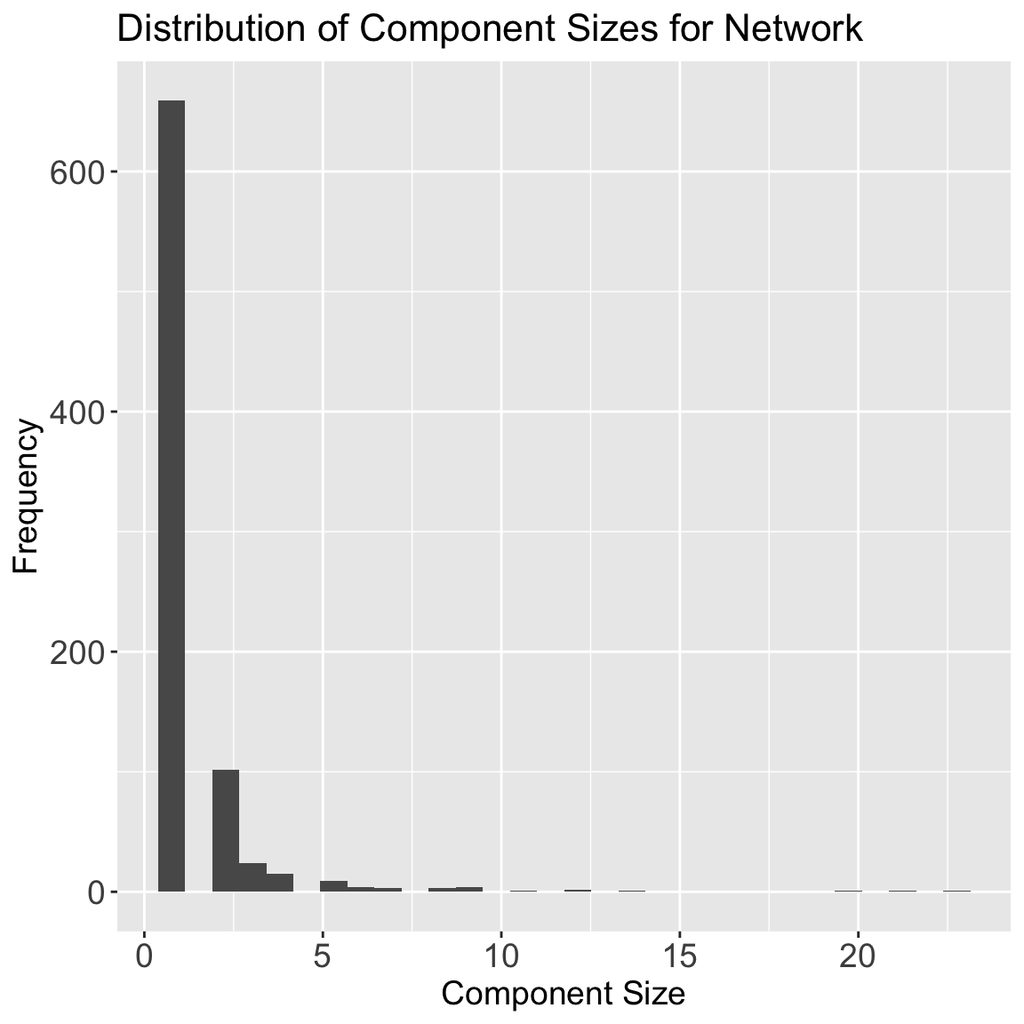

Following is a plot of the distribution of component sizes for the network on the log base 10 scale for both the component sizes and the frequencies. We see that there is at least an approximate negative linear association.

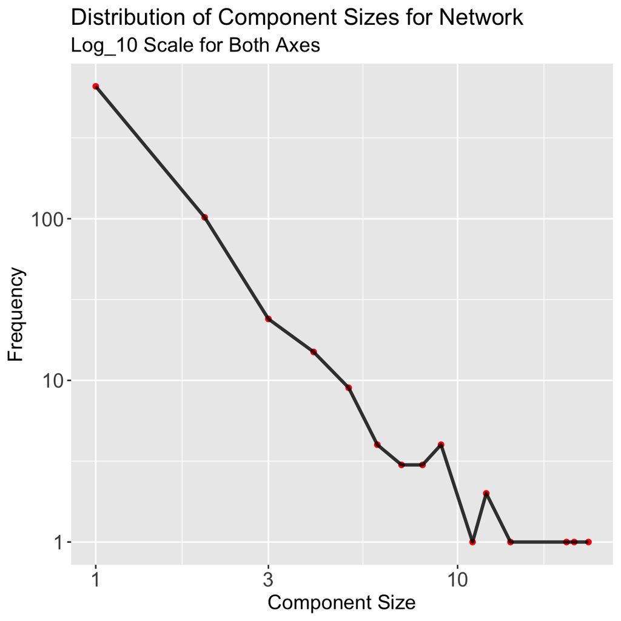

Following is a so-called “*rank-frequency plot*” of the log base 10 component sizes for the network versus the log base 10 rank of the component size (smallest rank is the **largest** component size). Tied ranks were averaged for simplicity of exploration. There is an obvious negative linear association. If we fit the model $\log_{10}(\text{size}_i) = \beta_0 - \frac{1}{\alpha}\log_{10}(\text{rank}_i - 0.5) + \varepsilon_i$, for $i = 1, \ldots, n$ components (Gabaix and Ibragimov 2011), then we obtain an estimated $\alpha$ of 1.91 (in a moment, we will talk about why we have this cryptic parameterization). I’ve added a fitted regression line for a reference.

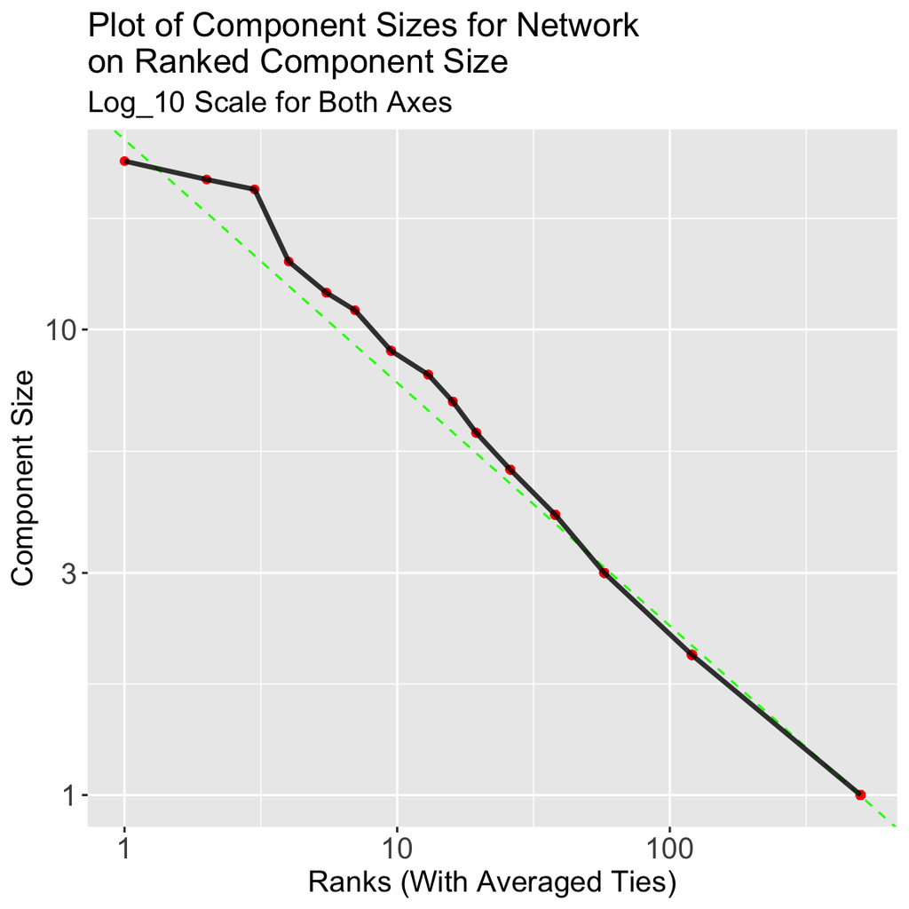

The power law probability mass function for (discrete) component size $S$ is:
$$P[S = s] = \frac{s^{-\alpha}}{\zeta(\alpha, x_{\rm min})}$$
where:
$$\zeta(\alpha, x_{\rm min}) = \sum_{n = 0}^{\infty}(n + x_{\rm min})^{-\alpha}$$
is the Hurwitz zeta function evaluated numerically in R. These are given in Gillespie (2015).

For our network, using the `poweRlaw` package in R, $x_{\rm min}$ is estimated to be 1, and $\alpha$ is estimated to be 2.75. This is a bit distant from the value of 1.91 using OLS above, but this later technique should be thought of as a blunt force method.

We now use bootstrapping to get a confidence interval for $\alpha$. Based on initial tuning, I used 3,000 bootstrap samples. The bootstrap distribution looked a touch right-skewed. A 95% bootstrap percentile confidence interval is [2.62, 2.91].

We now use the bootstrap test for power law goodness-of-fit described in Gillespie (2015) (his so-called Algorithm 2). After initial tuning, I ran 3,000 bootstrap samples and received a $p$-value of 0.7238. Hence, there is insufficient evidence to suggest the data are *not* from a power law distribution.

The plot below shows the frequency distribution of the component sizes (black dots), with implied zeros added where necessary, and our fitted power law distribution overlaid (green line).

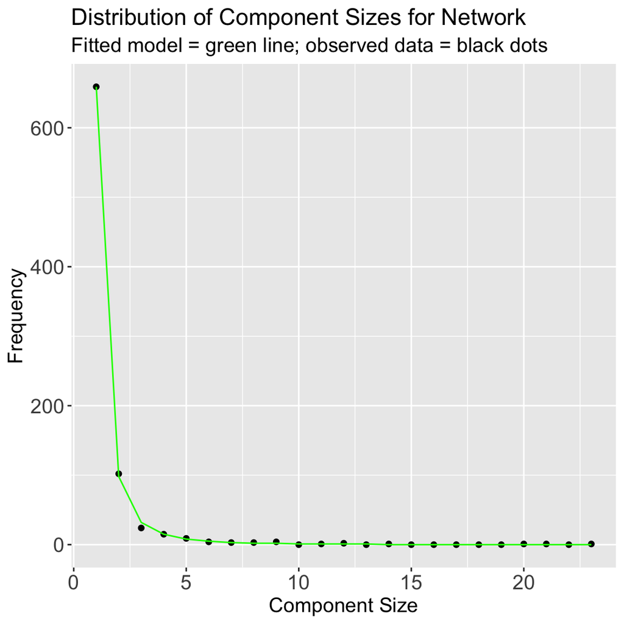

### Odds-and-Ends

- Given how nicely the power law distribution fit the data, and the nature of the problem, I was disinclined to explore other heavy-tailed distributions for now (e.g., exponential).
- I think the use of the power law distribution for this problem is reasonable. For example, it is well-known that city size follows a power law distribution. A moment’s reflection shows our situation to be analogous. That is, the nodes are the “citizens,” and the aggregation into components (albeit through genetic linkage) represent “cities.” Previous research shows the population of US cities follows a power law distribution with $\widehat{\alpha} = 2.30$, an estimate that is somewhat close to ours.
- Per the third point in New Modeling Attempt, I do not feel there is anything wrong with pooling the 100 simulations. In fact, in text analytics, this is routinely done. In our case, each sampling proportion setting represents the “corpus,” and a simulation represents a “document.” One could look at the simulation-specific empirical log-log distributions with a simulation envelope to get a sense of network-to-network variation. You could do worse than to use the median frequency (or rounded mean frequency) over simulations at each observed component size to get a sense of marginalized behavior for networks sampled at the given sampling fraction.
- Ravi brought up the point about how the sampling is done. In my mind, I view the method as follows. Take a one-shot SRSWOR of xx% nodes from the “population” network. Construct a “sample” network based on genetic distance and obtain the component sizes. (And I assume we hope the sample network is representative of the population network with respect to component sizes, taking into account reduced frequencies, variance being affected from large sampling fractions taken from a finite population, etc.) Ravi thinks of it differently, and uses a sequential approach. I will leave it to him to explain his thought process.

### Part 2: Examining Samples from Network at Sampling Fraction 0.95

Let the sampling fraction $f$ equal the sample size $n$ divided by the number of nodes, or population size, $N$. I use Gabby’s 100 samples where $f = 0.95$. This cooresponds to $n = 1,195$ nodes. The plot below shows frequency histograms of the component sizes for all 100 samples. Obviously, it is hard to see much, but there are small, meaningful differences from sample-to-sample.

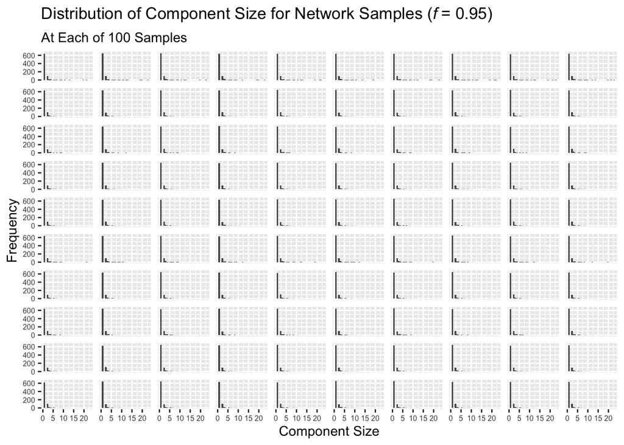

I then took each of the 100 samples and fit the power law model. In each case, I a.) obtained $\widehat{\alpha}$, and b.) computed the bootstrap test for power law goodness-of-fit exactly as described above. Total elapsed time, running 4 cores in parallel on my Mac, took a little over 2 hours; so, this is not a trivial undertaking.

The plot below shows the frequency distribution for the 100 sample $\widehat{\alpha}$’s. The red line represents the mean across 100 samples, while the green line represents the “population” $\widehat{\alpha} = 2.75$ from above. The difference between the red and green line is small and will have little practical effect for the work we do here.

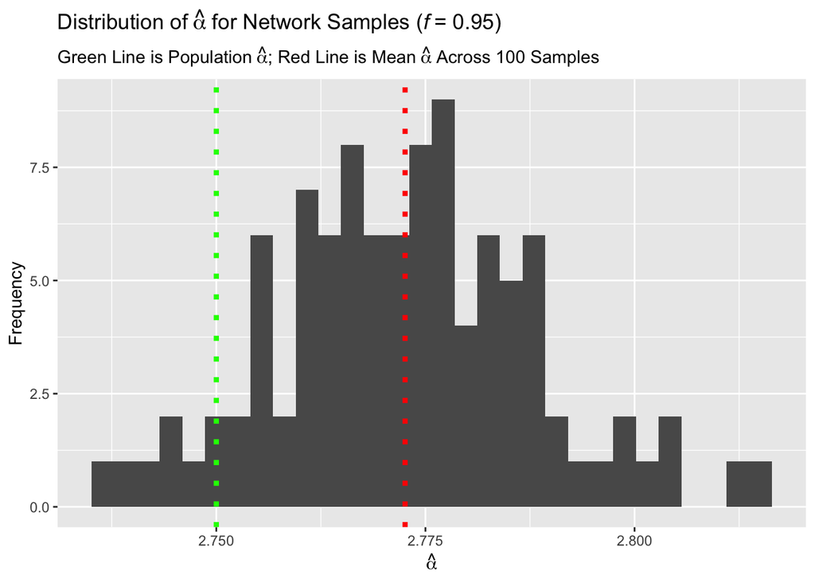

Next, we examine the frequency distribution for the $p$-values from the bootstrap test for power law goodness-of-fit conducted on each of the 100 samples. At least in this case, all the $p$-values are above 0.05 (the green line), but there is considerable variation among tests.

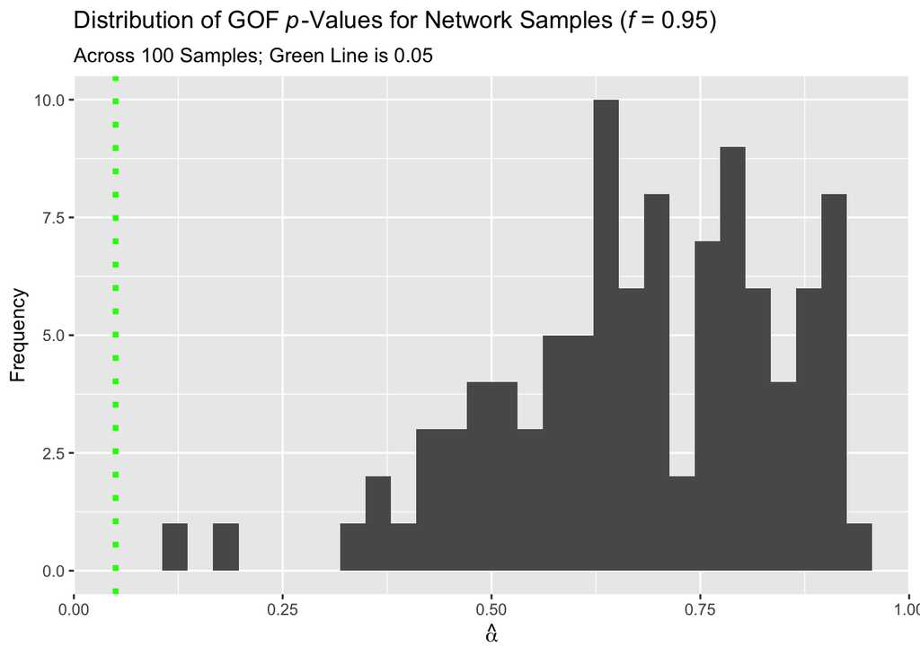

Care must be taken when working with samples drawn from networks because the frequencies of component sizes will necessarily decrease as $f$ decreases. Hence, for the following two graphs, it is best to use *relative* frequencies.

The following is a plot showing the relative frequency distributions for component size (log$_{10}$-log$_{10}$ scale) for all 100 samples *and* the population. For the most part, the samples are emblematic of the population (red line). However, the samples start to show differences out in the right tail. This is similar to a well-known problem in extreme value theory. Long, right tails are just hard to nail down.

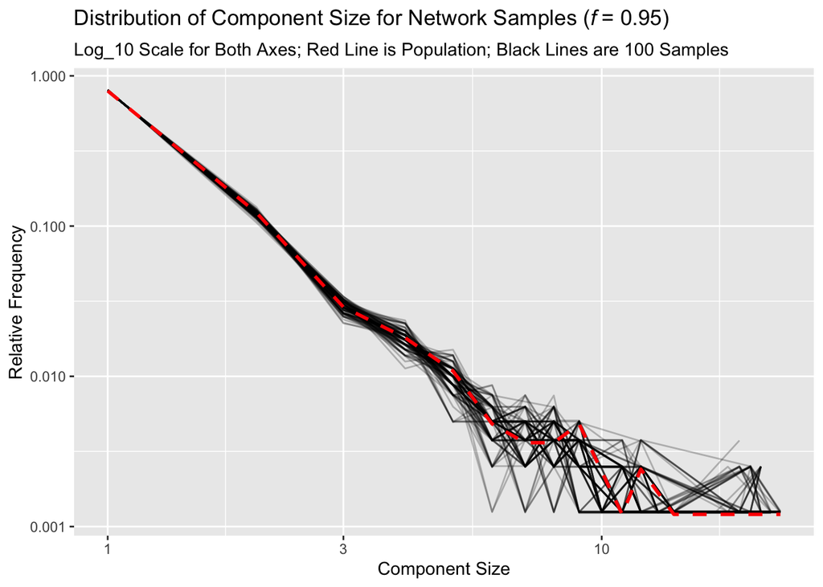

The following is a “do-over” of the previous plot. The blue, dashed line corresponds to the population. At each component size from 1-to-23, I took the minimum and maximum values of relative frequencies to form a “simulation envelope” (teal band). More samples would be needed to form a 95% simulation envelope. The red line corresponds to the median relative frequency; notice that it tracks nicely with the blue, dashed population line. The green line represents our fitted power law model from Part One. Much beyond a component size of 10, the power law underpredicts, albeit for very small relative frequencies. Note the log scale makes this apparent discrepancy look much worse than it is; indeed, the bootstrap test for power law goodness-of-fit for the population (in Part One) gave a $p$-value of 0.7238.

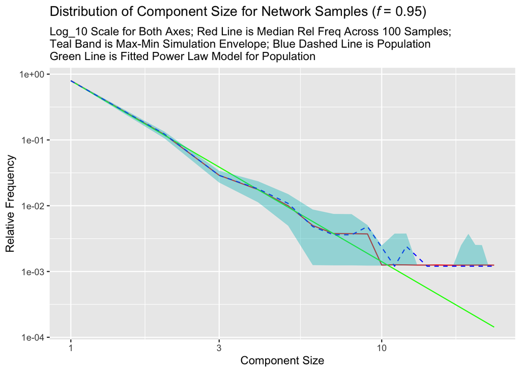

The approach given here would be more useful if we had more samples (1,000, say). We would then extend it to look at a sequence of sampling fractions $f$.

In closing, and as Ravi brought up last week, this report is not meant to suggest that a power law model will uniformly be “best” across all types of network compositions.

### References

Gabaix, Xavier, and Rustam Ibragimov. 2011. “Rank- 1/2: A Simple Way to Improve the OLS Estimation of Tail Exponents.” *Journal of Business & Economic Statistics* 29 (1): 24–39.

Gillespie, Colin S. 2015. “Fitting Heavy Tailed Distributions: The **poweRlaw** Package.” *Journal of Statistical Software* 64 (2). https://doi.org/10.18637/jss.v064.i02.